# Spring 2025 MLM Relational Rules Report - Experiment 2

Helen Peng

# 1 Rule Matching Model

```r
Phase2_RuleMatching_Model <- glmer(RealCorrect ~
                                   MatchedRule +
                                   (MatchedRule | Sub) +
                                   (MatchedRule | (Sub:Rule)),
                                   data = df_3KC_p2,
                                   family = binomial(),
                                   control=glmerControl(optimizer = "bobyqa"))
```

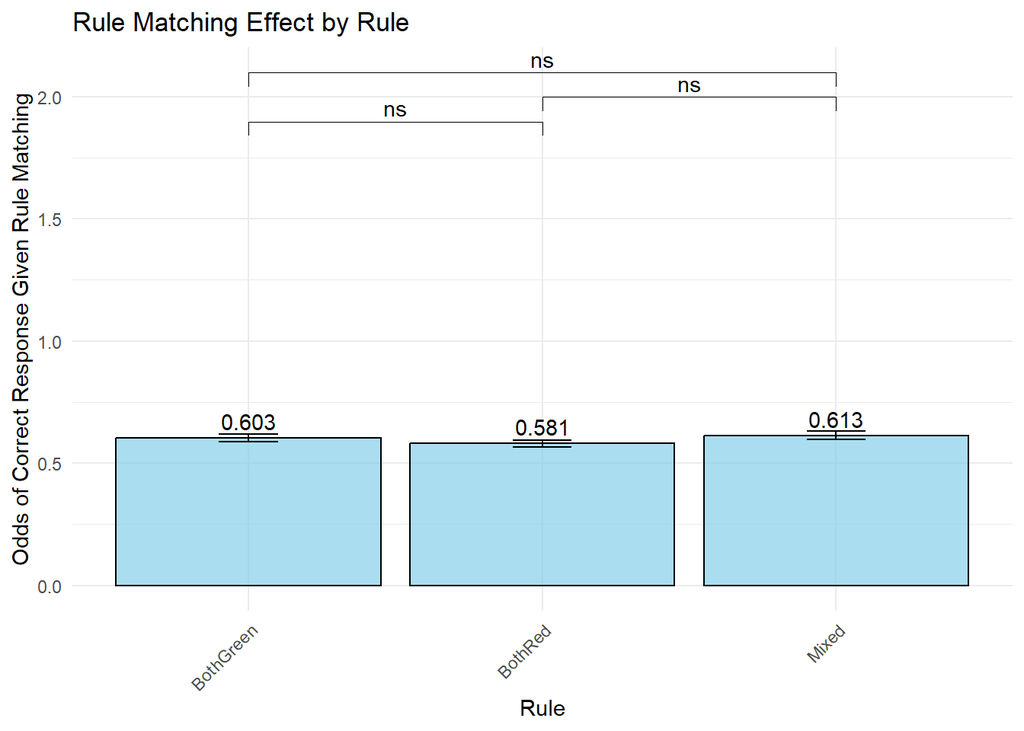

## 1.1 Multileveling Model Formation

Level 1 (Within-Subject Model)

$\text{logit}(\pi_{ijr}) = \beta_{0jr} + \beta_{1jr} \cdot \text{MatchedRule}_{ijr} + \epsilon_{ijr}$

where:

- $\pi_{ijr}$ is the probability of a correct response
- $\beta_{0jr} = 0.358$ is the subject-rule-specific intercept (baseline log-odds of a correct response)
- $\beta_{1jr} = 0.602$ is the subject-rule-specific slope for rule matching

Level 2 (Between-Subject and Between-Rule Models)

Models how the intercepts $\beta_{0jr}$ and slopes $\beta_{1jr}$ vary across subjects and subject-rule pairs

$\beta_{0jr} = \gamma_{00} + u_{0j} + v_{0jr}$

$\beta_{1jr} = \gamma_{10} + u_{1j} + v_{1jr}$

where:

- $\gamma_{00} = 0.358$ is the grand mean intercept
- $u_{0j} \sim N(0, \tau_{00_{Sub}} = 0.148)$ is the variability of subject means around the grand mean intercept
- $v_{0jr} \sim N(0, \tau_{00{Sub:Rule}} = 0.1511)$ is the subject-rule-level deviation
- $\gamma_{10} = 0.602$ is the grand mean slope
- $u_{1j} \sim N(0, \tau_{11_{Sub.MatchedRule}} = .16)$ is the subject-level deviation for slope
- $v_{1jr} \sim N(0, \tau_{11{Sub:Rule.MatchedRule}} = .75)$ is the subject-rule-level deviation for slope

## 1.2 Results

Fixed Effects: Pre-training on matching rules significantly improve accuracy (Estimate = 0.602, p < 0.001).

# 2 Interleaving Pretraining Model

```r
Phase2_Interleaved_Model <- glmer(RealCorrect ~
                                   InterleavedPT +
                                   (InterleavedPT | Sub) +
                                   (InterleavedPT | (Sub:Rule)),
                                   data = df_3KC_p2,
                                   family = binomial(),
                                   control=glmerControl(optimizer = "bobyqa"))
```

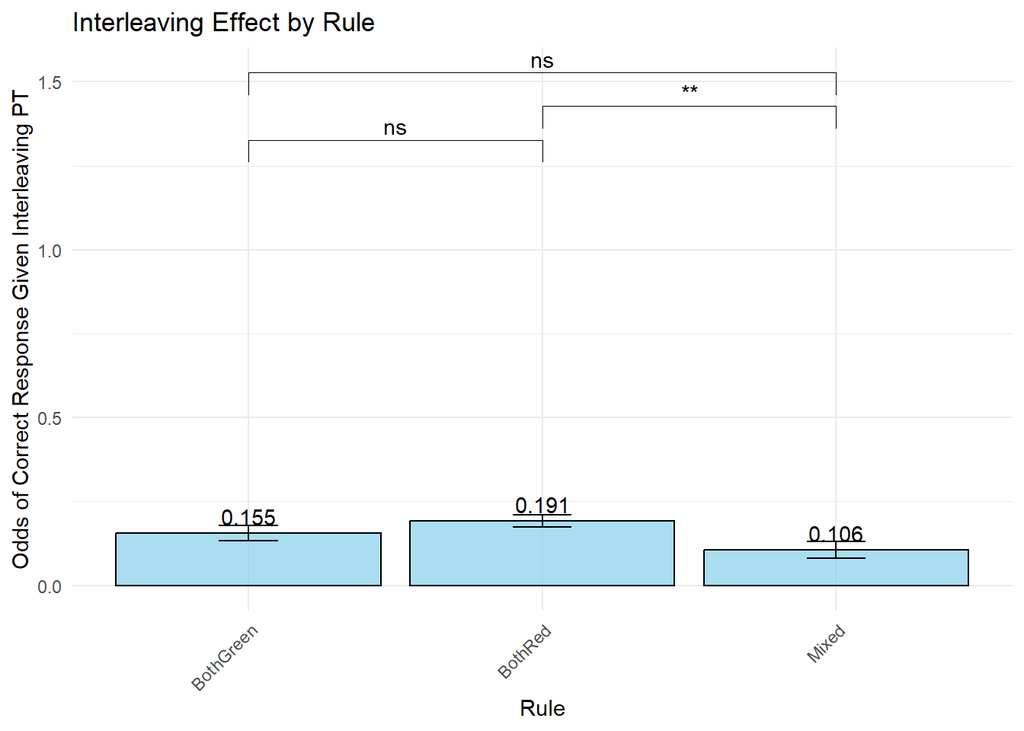

## 2.1 Multileveling Model Formation

Level 1 (Within-Subject Model)

$\text{logit}(\pi_{ijr}) = \beta_{0jr} + \beta_{1jr} \cdot \text{InterleavedPTTRUE}_{ijr} + \epsilon_{ijr}$

where:

- $\pi_{ijr}$ is the probability of a correct response
- $\beta_{0jr} = 0.45186$ is the subject-rule-specific intercept (baseline log-odds of a correct response)
- $\beta_{1jr} = 0.14853$ is the subject-rule-specific slope for interleaving pretraining

Level 2 (Between-Subject and Between-Rule Models)

Models how the intercepts $\beta_{0jr}$ and slopes $\beta_{1jr}$ vary across subjects and subject-rule pairs

$\beta_{0jr} = \gamma_{00} + u_{0j} + v_{0jr}$

$\beta_{1jr} = \gamma_{10} + u_{1j} + v_{1jr}$

where:

- $\gamma_{00} = 0.45186$ is the grand mean intercept
- $u_{0j} \sim N(0, \tau_{00_{Sub}} = 0.16)$ is the variability of subject means around the grand mean intercept
- $v_{0jr} \sim N(0, \tau_{00{Sub:Rule}} = 0.30)$ is the subject-rule-level deviation
- $\gamma_{10} = 0.14853$ is the grand mean slope
- $u_{1j} \sim N(0, \tau_{11_{Sub.InterleavedPTTRUE}} = 0.54)$ is the subject-level deviation for slope
- $v_{1jr} \sim N(0, \tau_{11{Sub:Rule.InterleavedPTTRUE}} = 0.47)$ is the subject-rule-level deviation for slope

## 2.2 Results

Random Effects Interpretation:

- InterleavedPTTRUE (1.16): The odds of answering correctly when given interleaving pretraining is 1.16 times the odds of answering correctly when there is no interleaving pretraining (but this effect is unreliable due to high p-value)
- $\sigma^2 = 3.29$: High unexplained variance in accuracy
- $\tau_{00 Sub:Rule} = 0.30$: Moderate baseline accuracy differences exist across subject-rule pairs.
- $\tau_{00 Sub} = 0.16$: Small differences in baseline accuracy between subjects.
- $\tau_{11 Sub:Rule.InterleavedPTTRUE} = 0.47$: Moderate variability in how interleaving affects accuracy across individuals.
- $\tau_{11 Sub.InterleavedPTTRUE} = 0.54$: Moderate variability in interleaving effects across subject-rule pairs.
- $\rho_{01 Sub:Rule} = -0.69$: For specific rules, higher baseline accuracy correlates with reduced benefits from interleaving.
- $\rho_{01 Sub} = -0.39$: At the subject level, higher baseline accuracy slightly reduces sensitivity to interleaving.
- $ICC = 0.14$: 14% of the variance in accuracy is due to subject-level differences.
- Marginal $R^2 = 0.001$, Conditional $R^2 = 0.137$ : Interleaving pretraining explains 0.1% of fixed-effect variance, while the full model (fixed + random) explains 13.7%
- Key Insights
  - **No Meaningful Benefit:** Unlike rule-matching, interleaving pre-training shows no statistically or practically significant impact on accuracy.
  - **Individual Differences Dominate**: Most variability in performance comes from unexplained factors or personal traits (random effects).
  - **Negative Correlation:** Higher baseline accuracy is linked to reduced benefits from interleaving, especially for specific rules.
  - **Unexpected Contrast:** The accuracy difference between BothRed and Mixed is significant, while BothGreen and Mixed is not. Post hoc, this makes sense for BothRed to be different from Mixed due to its harder rule, but the lack of difference for BothGreen remains unexplained. Further analysis was not conducted to determine why due to time constraint of the project.

# 3 Discussion

In this experiment, we explored how relational rule matching and interleaved pretraining influenced learning performance across mulitple knowledge components (KCs) using a mixed-effects logistic regression. Specifically, we evaluated whether participants showed differential improvement when their pretraining rule type aligned with test-phase rule types (“MatchedRule”), and how interleaving in pretraining affected performance in Phase 2.

## 3.1 Rule Matching and Learning Outcomes

The Rule Matching model revealed a robust positive effect of rule alignment. Participants were significantly more likely to respond correctly when the tested rule matched the one they had trained on during the pretraining phase. This supports our hypothesis that matched relational structures facilitate better transfer and application in novel tasks. The fixed effect coefficient for MatchedRule was substantial and positive, suggesting that alignment of training and test content plays a critical role in learners’ success—likely due to reduced cognitive load or improved schema integration. However, we also observed considerable variability in intercepts and slopes at both the subject and subject-rule levels, indicating that individual learners not only differed in their baseline performance but also in how much they benefited from matched rules. This heterogeneity could reflect differences in relational reasoning ability, prior exposure to similar tasks, or engagement with the pretraining phase.

## 3.2 Interleaving and Learning Outcomes

Interestingly, there was a negative correlation between baseline accuracy and the effectiveness of interleaving. Learners with higher initial accuracy appeared to benefit less from interleaving, particularly on specific rule types, possibly because the additional variability disrupted otherwise stable strategies. We also observed an unexpected contrast in rule performance: while the difference in accuracy between the BothRed and Mixed conditions was significant—likely due to BothRed being a more difficult rule—there was no such difference between BothGreen and Mixed. This lack of difference remains unexplained and was not further investigated due to time constraints.